# GSE91061 as a use case for VIBE

Last edited: 18 April, 2024

## Introduction to GSE91061 study

*Molecular portraits of tumor mutational and micro-environmental sculpting by immune checkpoint blockade therapy*

To demonstrate the application of VIBE on real-world data, we employed a publicly available melanoma dataset (GSE91061) , which comprises 109 samples from 65 patients to identify potential antibody therapy targets for patients who progressed on Nivolumab refractory patients (Riaz N et al., 2017; PMID: 29033130). This dataset includes 51 samples collected before Nivolumab treatment and 58 samples taken after treatment from 65 patients, complete with clinical outcome information (complete or partial responders (CR/PR), progressive disease (PD), and stable disease (SD)).

## Prepare environment and load required packages

```r
library(vibe)
library(GEOquery)
library(tidyverse)
```

## Download and preprocess the data from GEO

The downloading instructions can also be found on the GEO page of the study. The data was downloaded and counts were log normalized. BioMart was used to identify gene names and add it to the expression matrix.

```r
# load counts table from GEO
urld <- "https://www.ncbi.nlm.nih.gov/geo/download/?format=file&type=rnaseq_counts"
path <- paste(urld, "acc=GSE91061", "file=GSE91061_raw_counts_GRCh38.p13_NCBI.tsv.gz", sep="&");
tbl <- as.matrix(data.table::fread(path, header=T, colClasses="integer"), rownames=1)
```

```r
# pre-filter low count genes
## keep genes with at least 2 counts > 10
keep <- rowSums( tbl >= 10 ) >= 2
tbl <- tbl[keep, ]

# log transform raw counts
## instead of raw counts can display vst(as.matrix(tbl)) i.e. variance stabilized counts

## Other normalization techniques can be used in order to generate RPKM/TPM values etc
expr <- as.data.frame(log10(tbl + 1))

#Add Ensembl gene Ids and gene names to the expression matrix

library(biomaRt)
mart <- useMart("ensembl", dataset = "hsapiens_gene_ensembl")
gene_symbols <- getBM(attributes = c('entrezgene_id', 'external_gene_name','ensembl_gene_id'),
                      filters = 'entrezgene_id',
                      values = rownames(expr),
                      mart = mart )

expr$entrezgene_id <- row.names(expr)
expr$entrezgene_id <- as.character(expr$entrezgene_id)
gene_symbols$entrezgene_id <- as.character(gene_symbols$entrezgene_id)

expr_gene <- left_join(expr, gene_symbols, by = "entrezgene_id")

## Split data into numeric and character columns
numeric_cols <- sapply(expr_gene, is.numeric)
character_cols <- sapply(expr_gene, is.character)

## Calculate average of rows with same gene
expr_gene_averaged <- expr_gene %>%
  group_by(external_gene_name) %>%
  summarize(across(where(is.numeric), mean, na.rm = TRUE),  # Calculate mean for numeric columns
            across(where(is.character), ~paste(unique(.x), collapse = ",")),  # Concatenate character columns
            .groups = 'drop')  # Drop grouping

## Remove rows with no gene names
expr_gene_averaged <- expr_gene_averaged[!is.na(expr_gene_averaged$external_gene_name),]
expr_gene_averaged <- expr_gene_averaged[!expr_gene_averaged$external_gene_name %in% "",]


## Conver expression matrix into long format to be used for VIBE

expr_gene_long <-  expr_gene_averaged %>%
                pivot_longer(
                  cols = -c(entrezgene_id, external_gene_name, ensembl_gene_id),
                  names_to = "Patientid",
                  values_to = "log_counts"
                )
```

## Load metadata of GSE91061

The consolidated metadata was generated manually by combining information from GEO and the manuscript of study Riaz N et al., 2017 (PMID: 29033130). The metdata is combined with the expression matrix

```r
gse91061_metadata <- read.table("GSE91061_Metadata.tsv", sep="\t", header = T)

## Combine metadata with expression matrix
expr_metadata <- left_join(expr_gene_long, gse91061_metadata, by = c("Patientid" = "GEO_ID"))

expr_metadata <- expr_metadata[!is.na(expr_metadata$external_gene_name),]
```

## Generating list of genes and signatures for generating the VIBE visuals

```r
## list of genes related to surfaceome from GSE91061

genes_surfaceome <- c("BCAN","DCT","DLL3","EPHA5","GPR143","MCOLN3","MDGA2","MLANA","SLC6A17","TYRP1","HCN1","NRG3","GABRB3","CD247","CD3D","CD3G","CD7","CD8A","CD8B","CTLA4","CXCR6","DNER","FASLG","ICOS","KLRC2","LAG3","PDCD1","PRF1","SIRPG","SIT1","TNFRSF9")

## List of genes indicative of the presence of Tregs, T cell activation, T cell infiltration, T cell exhaustion, CD3 cells, CD8 cells, and T cell cytotoxicity [Tc1, Tc2, Tc3 and Tc4] each evaluated individually

Treg_signature <- c("CD69","ENTPD1","FOXO1","FOXP3"," IKZF4"," IL10"," IL10RA"," IRF4","JAK1","NT5E","PRDM1","SMAD2","SMAD3"," STAT3","STAT5A","TGFB1","TGFBR1","TGFBR2","TYK2")

Tcell_activation <- c("IL2RA","TFRC", "DPP4" ,"CD27", "CD28","TNFRSF8", "CD40LG","TNFRSF4")

Tcell_infiltration<- c("CD2","CD247","CD28","CD3D","CD3G","CD6","GPR171","GZMK","ICOS","ITK","KLRB1","PYHIN1","TIGIT","TRAT1","CD4","CD8A","CD8B","TRBC1")

Tcell_exhaustion <- c("B3GAT1","BATF","CASP3","CCL3/L1","CD160","CD244","CD86","CTLA4","EOMES","FASLG","HAVCR2"," IRF4"," KLRG1","LAG3","LILRB4","MDFIC","PDCD1","PDPN","PROCR","PTGER2","TIGIT","TNFRSF9","TNFSF9","TOX")

CD3 <- c("CD3D", "CD3E","CD3G")
CD8 <- c("CD8A","CD8B")

Tc1 <- c("TNF", "INFG", "IL2", "CXCR3", "TBX21")
Tc2<- c("IL4", "IL5", "CCR4", "GATA3")
Tc9 <- c("IL9", "IL10", "IRF4")
Tc17 <- c("CCR6", "KLRB1", "IL17", "IRF4", "RORC")

## Fetch unique gene names from the above list of genes and signatures
gene_panel <- unique(c("BCAN","DCT","DLL3","EPHA5","GPR143","MCOLN3","MDGA2","MLANA","SLC6A17","TYRP1","HCN1","NRG3","GABRB3","CD247","CD3D","CD3G","CD7","CD8A","CD8B","CTLA4","CXCR6","DNER","FASLG","ICOS","KLRC2","LAG3","PDCD1","PRF1","SIRPG","SIT1","TNFRSF9", Treg_signature, Tcell_activation, Tcell_infiltration, Tcell_exhaustion,CD3, CD8, Tc1, Tc2, Tc9, Tc17))

## Create a list of gene and signatures for VIBE visuals
gene_panel_list <- list("BCAN","DCT","DLL3","EPHA5","GPR143","MCOLN3","MDGA2","MLANA","SLC6A17","TYRP1","HCN1","NRG3","GABRB3","CD247","CD3D","CD3G","CD7","CD8A","CD8B","CTLA4","CXCR6","DNER","FASLG","ICOS","KLRC2","LAG3","PDCD1","PRF1","SIRPG","SIT1","TNFRSF9", Treg_signature, Tcell_activation, Tcell_infiltration, Tcell_exhaustion,CD3, CD8, Tc1, Tc2, Tc9, Tc17)

## Add names to the list of gene and signatures for VIBE visuals
names(gene_panel_list) <- c("BCAN","DCT","DLL3","EPHA5","GPR143","MCOLN3","MDGA2","MLANA","SLC6A17","TYRP1","HCN1","NRG3","GABRB3","DNER","CD247","CD3D","CD3G","CD7","CD8A","CD8B","CTLA4","CXCR6","FASLG","ICOS","KLRC2","LAG3","PDCD1","PRF1","SIRPG","SIT1","TNFRSF9","Treg_signature","Tcell_activation","Tcell_infiltration","Tcell_exhaustion","CD3", "CD8","Tc1","Tc2","Tc9","Tc17")
```

## Harmonize GSE91061 data for VIBE

The expression matrix is harmonized for the VIBE visuals. The harmonized dataframe is used to create signature specific matrix for plotting. Also, additional metadata information is added.

```r
## subset the expression matrix for the genes of interest
expr_metadata <- expr_metadata[expr_metadata$external_gene_name %in% gene_panel,]
expr_metadata$indication <- "SKCM"
## Harmonize the dataset using VIBE
df_harmonized <- harmonize_df(
  df = expr_metadata,
  col_patientid = "Patient_number",
  col_sampleid = "Patient_tag",
  col_indication = "indication",
  col_treatment = "Treatment",
  col_symbol = "external_gene_name",
  col_value = "log_counts",
  unit = "log counts",
  keep_extra_cols = "Response_Final")

#df_harmonized$group1 <- paste0(df_harmonized$Response_Final, " ", df_harmonized$treatment)

dataset_name = "GSE91061"

## Generate signature specific harmonized dataset for the plotting using VIBE

df_avg_pathways <- harmonize_df_pathway(df_harmonized, gene_panel_list)

## Add metadata to the signature related expression matrix
df_avg_pathways <- left_join(df_avg_pathways, gse91061_metadata, by = c("sampleid" = "Patient_tag"))

## Filter out samples with no information on responses
df_avg_pathways <- df_avg_pathways[!df_avg_pathways$Response_Final %in% c("UNK","NE"),]

## Create additional metadata columns for plotting
df_avg_pathways$group1 <- paste0(df_avg_pathways$Response_Final, " ", df_avg_pathways$treatment)
df_avg_pathways$group1  <- factor(df_avg_pathways$group1, levels = c("PRCR pre", "PRCR post", "PD pre","PD post","SD pre","SD post"))
```

## Heatmap representing the expression of the selected genes and user-defined signatures in response and outcome categories at baseline

The expression of the selected surfaceome genes and T cell-signatures pathways was visualized using a heatmap across response and treatment categories at baseline. As anticipated, a set of genes or pathways, including PDCD1, CD3, and the Treg signatures, were overexpressed in patients exhibiting a CR/PR as compared to SD and PD.

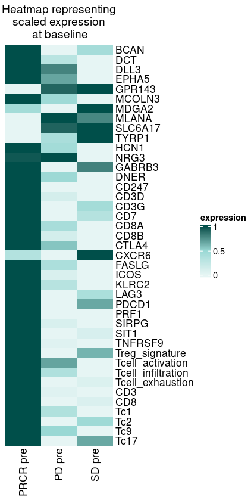

```r
heatmap_baseline
heatmap_baseline

dev.off()
```

## Barplot representing the percentage of samples with high expression of PDCD1 and CD3 in response and outcome categories

Barplot shows that a high percentage of samples, both pre- and post-treatment, with above-median expression levels of PDCD1 and CD3 were observed in patients exhibiting CR/PR , as well as in post-treatment SD patients, indicating that these markers may be predictive of positive treatment outcomes on nivolumab.

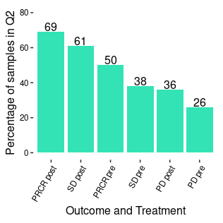

```r
plot_perc_pop(df = df_avg_pathways, target1 = "CD3", target2 = "PDCD1", threshold_method = "median", QOI = "Q2", order = "T", grouping_var = "group1") +
  ylim(0,80)+
  xlab("Outcome and Treatment") +
  theme(plot.caption = element_blank(),
        plot.title = element_blank())
```

```r
NA
NA
```

## Scatterplot representing distribution of samples in four quadrants based on expression of TYRP1 and Tc1

The plots are colored based on the expression of CD3. The correlation and P-value are reported in the scatterplot along with the %samples in Q2 quadrant.

28% of post-treatment SD samples had a relatively high expression of both TYRP1 and the Tc1 signature. Overall, the correlation between the two was non-significant or negative across the different outcome groups.

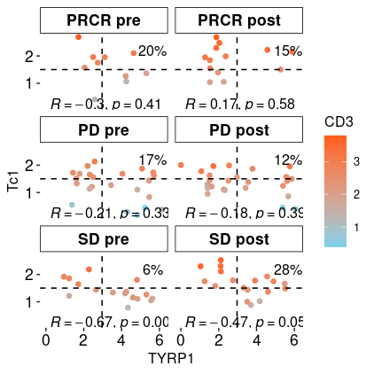

```r
plot_expression_scatter(df = df_avg_pathways,
                        target1 = "TYRP1",
                        target2 = "Tc1", target3 = "CD3",
                        QOI = "Q2",
                        cor_method = "spearman",
                        threshold_method = "median", grouping_var = "group1",
                        dataset = dataset_name, facet_ncol = 2)+
  theme(plot.title = element_blank(),
        plot.caption = element_blank())
```